# STUDENTLAB

Adaline Powell

2024-04-05

The advantages associated with higher-income backgrounds are widely acknowledged by researchers. Individuals from such backgrounds typically have greater access to resources, offering them more opportunities and resources to achieve success. However, how does this relationship act in the academic lives of children, particularly in terms of their test scores?

In this lab, I will use the student dataset to investigate the dynamics of this relationship. The dataset comprises scores on standardized tests (ranging from 1 to 100), income levels (categorized from 1 to 12), and SCH_ID, which notes the school attended by each student. Given the large number of schools in the dataset, I have used a random number generator to select a subset of 8 schools for investigation. These schools are identified by their respective SCH_IDs: 24, 137, 255, 388, 412, 173, 306, and 421. Through this analysis, I aim to explore how income levels correlate with students’ test scores across these selected schools.

#### Hypothesis: Students from higher-income backgrounds tend to perform better on test scores compared to their peers from lower-income backgrounds, while controlling for school.

Figure one displays a normal linear model, producing a single OLS line.

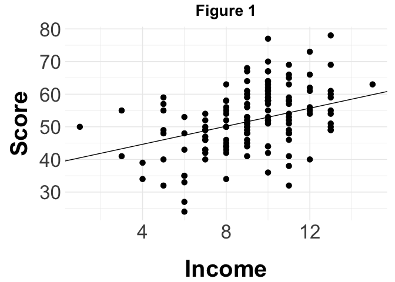

Figure 2 is exactly the same and the previous figure, although the data poitns are further distiguished by their schools. In this scenario, where the data involves students nested within schools, it is essential to consider the hierarchical nature of the data. Students are clustered within schools, meaning that students within the same school may be more similar to each other than to students in other schools. Ignoring this hierarchical structure could lead to biased estimates and incorrect conclusions.

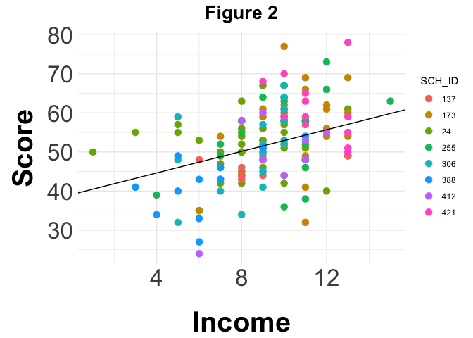

I will be utilizing a random effect because I anticipate that income will have a consistent impact across all schools, although certain schools may offer environments where the majority of their students achieve higher scores. Upon examining Figure 2, which factors in the schools attended by the students, distinct patterns emerge among income levels. Notably, it seems that school ID 421 may have a negative relationship with scores and income. This provides further justification for employing a random effect rather than a fixed one in the analysis.

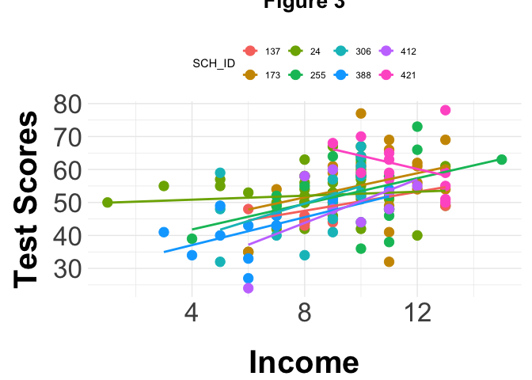

Table 1

|  | score |  |  |
| --- | --- | --- | --- |
| Predictors | Estimates | CI | p |
| (Intercept) | 33.75 | 25.49 – 42.01 | **<0.001** |
| income | 1.99 | 1.16 – 2.82 | **<0.001** |
| Random Effects |  |  |  |
| σ<sup>2</sup> | 72.46 |  |  |
| τ<sub>00</sub> <sub>SCH_ID</sub> | 58.11 |  |  |
| τ<sub>11</sub> <sub>SCH_ID.income</sub> | 0.55 |  |  |
| ρ<sub>01</sub> <sub>SCH_ID</sub> | -1.00 |  |  |
| ICC | 0.05 |  |  |
| N <sub>SCH_ID</sub> | 8 |  |  |
| Observations | 143 |  |  |
| Marginal R<sup>2</sup> / Conditional R<sup>2</sup> | 0.232 / 0.272 |  |  |

Turning to Table 1 and interpreting the estimates, the random effect in O2 captures the variability of the data points, specifically the school ID points, around the mean when the variable is taken into account. Interpreting this, within the variance of school ID groups, I anticipate a variability of approximately 72 points. In τ00, the between-school effect is manifested when we allow our slopes to vary, resulting in approximately 58.11 units of variance around the intercepts. This captures the variability of data points (school IDs) around the grand intercept, while controlling for the variable (income). In τ11, the term describes how the income slopes vary around the grand mean slopes. With a value of 0.55, it indicates that the slopes do not vary significantly across schools. This suggests a relatively consistent relationship between income and test scores across different schools, with minimal variation observed in the slopes between them. For ρ01, the correlation between the variances of random intercepts and random slopes is typically expected to range from -1 to 1. A correlation value close to 0 indicates minimal correlation, while values approaching -1 or 1 suggest stronger correlations. Ideally, we aim for low or non-existent correlation to avoid issues in model estimation. However, a correlation value of -0.99 indicates a problem, as it suggests a perfect negative correlation, which is rarely encountered in practice and may signal issues with the model. As for ICC, it measures the proportion of variance in the outcome variable that is attributable to the clusters (in this case, schools) when accounting for random slopes. A value of 0.05 suggests that only a small portion of the variance is being explained by the clusters, indicating that the school-level effects, when considering random slopes, are not substantial. This low ICC value suggests that the clusters (schools) are not explaining much of the variability in the outcome variable, which may indicate limited clustering effects at the school level.

The majority of schools exhibit a positive relationship between test scores and income, providing support for the hypothesis that higher incomes are likely to result in higher test scores. However, an interesting exception is observed with school ID 421, where a negative relationship is evident. Notably, most data points cluster towards higher income levels, typically between levels 9 and 13.